# DCS 375 Final Writeup

Dieter Villegas, Liza Dubinsky, Quinn Macauley, Jenniflore Beaubrun

4/22/2022

## Final project for DCS 375 on Players in the 2018 World Cup Semifinal and Final

### Introduction

In this project, we used Statsbomb event data from the [Dato-Futbol/passing-networks GitHub repository](https://github.com/Dato-Futbol/passing-networks) to analyze the final and semifinal games in the 2018 World Cup. Motivated by scholarly articles on constructing and analyzing passing networks, we used network analysis to explore the following questions:

1. What players are central to the directed networks of the France-Croatia final and France-Belgium semifinal? What positions do they play?
2. How are the number of passes allocated across players on each team?

### Background

The most popular sport in the world brings forth a complexity when looking beyond the score and using methods, metrics, and visualization to analyse a game. There are many events that occur in one soccer match such as shots, goals, passes, fouls, among many others. There are multitude amounts of statistics that are be used to analyse a player, a position, or a whole team. There a variety of competitions national teams can participate in. The World Cup, played ever 4 years, is the biggest stage to play for any soccer player and national team. We choose to analyze the current reigning champions of the world, France, and their trajectory through the semi-final game and final game as well as their opponents in these games. There has been a total of 21 World cups France has qualified 15 times to the competition. France has made it to the semifinals or further in 6 occasions and winning it twice. Currently they are considered one of the best teams, being ranked 3rd in the FIFA men’s ranking.

In many soccer games a man of the match is selected and it usually goes to a player that effectively contributed the most in the game. The contribution of the player can range from scoring a decisive goal to a goalkeeper keeping a clean sheet after many chances from the counter-part. Using this idea of MOTM, we want to explore the team and it’s player’s significance in the game based on their number of passes. Passing networks are an example to mathematically and visually analyze what happens in the pitch and how players interact with each other throughout the game. Many times key players are not the ones who score the goals, but the ones that allow for the creation of scoring chances. This project studies individual player’s passing contributions to further understand a team’s dynamic and the players themselves. We do not take into account current position of a player at the moment of the pass or it’s difficulty, but rather it’s overall presence with the ball and with it’s teammates.

### Methodology and Discussion

In the following sections, we include our methodology for our analyses followed directly by our discussion of the relevant results and visualizations.

#### Filtering the Data

The below code allowed us to isolate only the passing plays for our analyses, as well as create 2 datasets and write 2 .csv files for the final and semifinal games:

```r
# grab only the passes from the types of plays
network_passes <- subset(wc_df_official, type.name == "Pass")

# create 2 data sets for 2 games we plan to analyze by taking subset of original dataset for two teams per game
france_croatia_final <- subset(network_passes, possession_team.name == c("France", "Croatia"))

france_belgium_semi <- subset(network_passes, team.name == c("France", "Belgium"))

# write 2 csv files for each of these games
write.csv(france_croatia_final, "france_croatia_final.csv", row.names = FALSE)

write.csv(france_belgium_semi, "france_belgium_semi.csv", row.names = FALSE)
```

Using these .csv files, we filtered the data further to remove any extraneous rows from other games, remove players who didn’t play in either the final or semifinal, and isolate only the connected passes by removing any pass outcomes that were “Incomplete”, “Out”, or “Unknown”. The below code is for the French team in the France-Croatia final:

```r
# clean the data frame to only include passes from france and croatia final
# reading in csv so that we don't have to re-run top part in case of a premature change to players
team_name_france_croatia_final <-  read.csv("france_croatia_final.csv")

team_name_france_croatia_final <- subset(team_name_france_croatia_final, team.name == c("France", "Croatia"))

# remove players who did not play for france in the final
france_only_final <- subset(team_name_france_croatia_final, team.name == "France")
france_only_final <- subset(france_only_final, player.name  != "Steve Mandanda")
france_only_final <- subset(france_only_final, pass.recipient.name  != "Steve Mandanda")

france_only_final <- subset(france_only_final, player.name != "Presnel Kimpembe")
france_only_final <- subset(france_only_final, pass.recipient.name != "Presnel Kimpembe")

france_only_final <- subset(france_only_final, player.name != "Thomas Lemar")
france_only_final <- subset(france_only_final, pass.recipient.name != "Thomas Lemar")
```

```r
# construct french final dataset for connected passes only
connected_pass_france_final <- subset(france_only_final, is.na(pass.outcome.name))
```

#### Creating Network Objects

We then used the player name and pass recipient name columns of our datasets to create an edgelist and then a network object of connected passes to and from players on each team in both games. The below code is for the French team in the France-Croatia final:

```r
# create an edgelist of passes to and from players
france_final <- cbind(connected_pass_france_final$player.name, connected_pass_france_final$pass.recipient.name)

# name these columns
colnames(france_final) <- c("from", "to")

# create a graph object for network analysis
france_final.g <- graph.edgelist(france_final, directed = TRUE) # makes a graph object
```

#### Visualizing Directed Networks

To create accessible network visualizations, we used shape and color to distinguish between the positions played by player in each team across both games. The goalkeeper is a yellow sphere, the defenders are blue circles, the midfielders are purple squares, and the forwards are green rectangles. The below code assigns players on the French team to different positions and defines the color and shape of each player node based on their position:

```r
# create vectors to identify French players based on their position
france_midfielder <- c("Corentin Tolisso", "Paul Pogba", "N''Golo Kanté", "Blaise Matuidi", "Steven N''Kemboanza Mike Christopher Nzonzi", "Thomas Lemar", "Florian Thauvin")
france_defender <- c("Benjamin Pavard", "Samuel Yves Umtiti", "Raphaël Varane", "Lucas Hernández Pi", "Presnel Kimpembe", "Djibril Sidibé", "Benjamin Mendy")
france_forward <- c("Ousmane Dembélé", "Kylian Mbappé Lottin", "Antoine Griezmann", "Nabil Fekir", "Olivier Giroud")
france_goalkeeper <- c("Hugo Lloris")

# specify color and shape of player nodes based on their position
V(france_final.g)[V(france_final.g)$name %in% france_midfielder]$color <- "#440154"
V(france_final.g)[V(france_final.g)$name %in% france_midfielder]$shape <- "square"
V(france_final.g)[V(france_final.g)$name %in% france_defender]$color <-"#31688e"
V(france_final.g)[V(france_final.g)$name %in% france_defender]$shape <- "circle"
V(france_final.g)[V(france_final.g)$name %in% france_forward]$color <- "#35b779"
V(france_final.g)[V(france_final.g)$name %in% france_forward]$shape <- "rectangle"
V(france_final.g)[V(france_final.g)$name %in% france_goalkeeper]$color <- "#fde725"
V(france_final.g)[V(france_final.g)$name %in% france_goalkeeper]$shape <- "sphere"
```

To save the layouts for our network visualizations, we set a seed for each team in each game. Then, using a soccer field background and our network visualization, we scaled and offset the network to create a composite of both images. Below is the code for both France and Croatia in the France-Croatia final:

```r
# set specific seed to get the same shape of the network every time and write network file for france final passing network
set.seed(11)
png(file="france_final.png", width=1000, height=1000)
par(bg="transparent")
plot(france_final.g, vertex.size = 20, vertex.label.cex = 1, vertex.label.color = "white")

# set specific seed to get the same shape of the network every time and write network file for croatia final passing network
set.seed(10)
png(file="croatia_final.png", width=1000, height=1000)
par(bg="transparent")
plot(croatia_final.g, vertex.size = 20, vertex.label.cex = 1, vertex.label.color = "white")
dev.off()
```

```r
# read in soccer field background and network files for french and croatian passing networks
soccer_png <- image_read("soccer_fil.png")
france_png_final <- image_read("france_final.png")
croatia_png_final <- image_read("croatia_final.png")

# so we dont have to re-read images from above
france_png_final <- france_png_final
croatia_png_final <- croatia_png_final
soccer_field <-soccer_png

# adding alt text to the image of the soccer field
soccer_field_france_final <- image_annotate(soccer_field, "Figure 3: France's passing network in the 2018 World Cup Final against Croatia", size = 15, font = "Times",gravity = "west", color = "white", location = "+55+295")

soccer_field_croatia_final <- image_annotate(soccer_field, "Figure 4: Croatia's passing network in the 2018 World Cup Final against France", size = 15, font = "Times",gravity = "east", color = "white", location = "+55+295")

# scaling french and croatian passing network images to 1000 height
france_png_final <- image_scale(france_png_final, "x1000")
croatia_png_final <- image_scale(croatia_png_final, "x1000")

#creating a composite of both images and moving the french and croatian networks using offset to the right and down
# scaling the soccer field to 1000 in height
final_france_image <- image_composite(image_scale(soccer_field_france_final, "x1000"), france_png_final, offset = "-500-50")
final_croatia_image <- image_composite(image_scale(soccer_field_croatia_final, "x1000"), croatia_png_final, offset = "+0")
```

##### France in the 2018 World Cup Semifinal

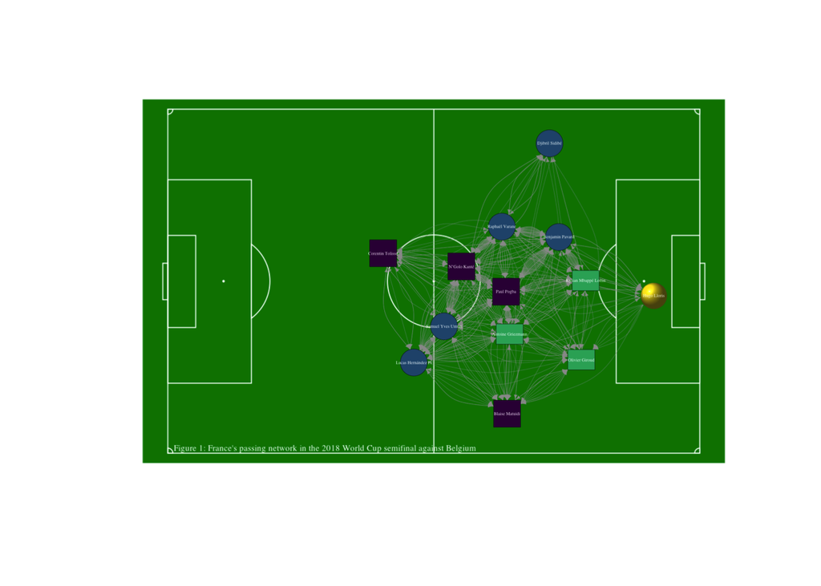

```r
# plot the france passing network from the World Cup semifinal on soccer field
plot(semi_france_image)
```

The above plot is a directed network showing the passes from and to each player. We can observe that a great concentration of edges between Pavard, Mbappe, Pogba, and Varane. These players represent the right side of the french lineup and are considered a lot more attacking that its left side. The attacks coming from this side is not surprising because in the the right side, Pavard is a very offensive defensive player that participates in sending crosses or connecting with strikers. This is shown with by amount of passes with Mbappe and Pogba. In comparison, french’s left side consisting of defender Hernandez and Umtiti have a much lower connection with the forwards. They mostly pass with each other or the center midfielders. The lack of connection between Varane , Pavard and Umtiti Hernandez shows that during this game the defenders did not swing the ball much in the back. This can due to the fact that the Belgian team was attacking and pressing quite bit.

##### Belgium in the 2018 World Cup Semifinal

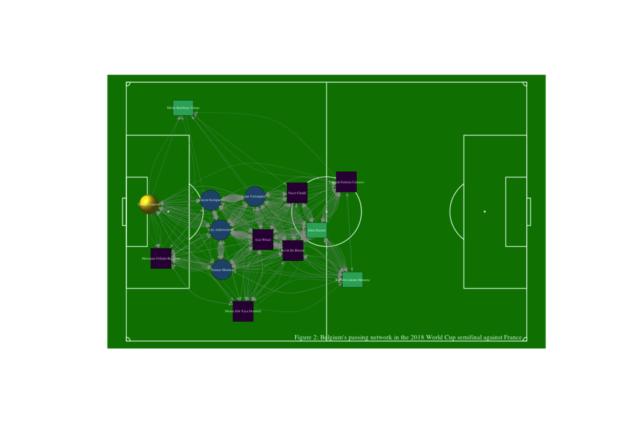

```r
# plot the belgium passing network from the World Cup semifinal on soccer field
plot(semi_belgium_image)
```

The directed passing network above represents the Belgium’s passing from and to each player. Belgium had a significantly greater amount of possession than France. This can be seen with the passing among their defenders and midfield. However, they lacked an attacking component having fewer shots than France and its reflected with the lack of passing to the forwards. Additionally, De Bruyne is has an important presence in the attacking, but this game the passes he completed did not go as forward as the usual. He was restrained to passing through the middle. This can possibly be granted to the French emphasis on shutting him down quickly and forcing him to play back.

##### France in the 2018 World Cup Final

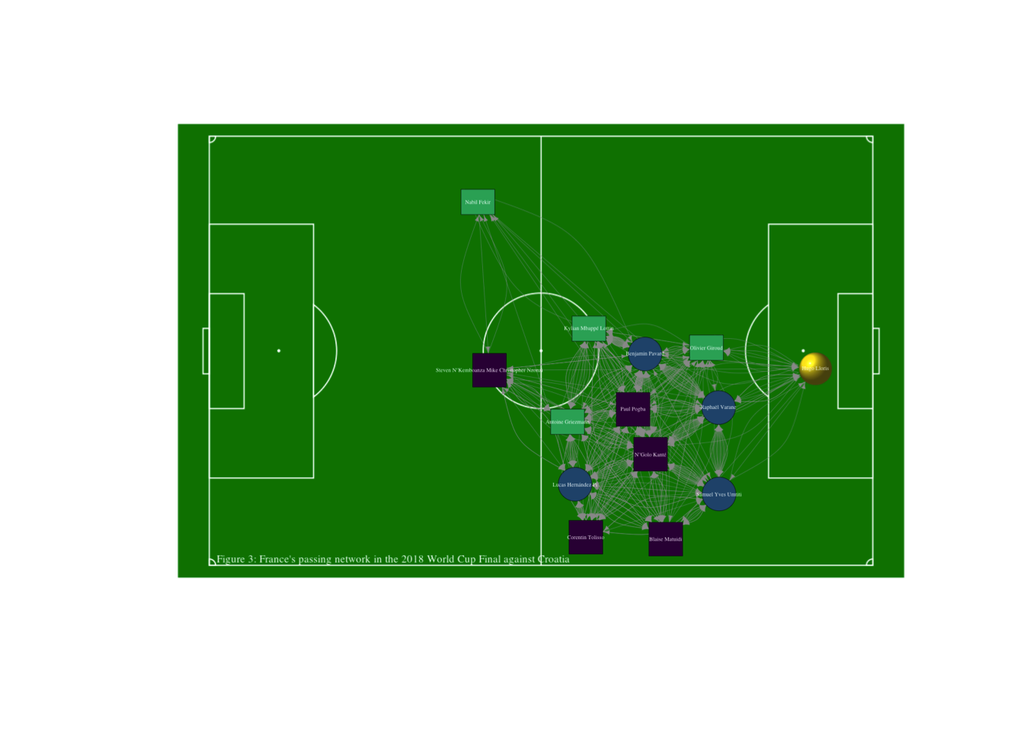

```r
# plot the france passing network from the World Cup final on soccer field
plot(final_france_image)
```

The plot above represents Frances passing network in the world cup final. Similar to the semifinal Varane, Pavard, Mbape, and Pogba have significant amount of connections. Additionally, Kante also has a lot of connections with everyone. This shows how France continues to attack to from the right side of the field. Though during this game the left side defenders, midfields and forwards have a greater number of connections between. It seems like they increase their attack through the left side which corresponding to 4 goals, compared to only one in the semifinal.

##### Croatia in the 2018 World Cup Final

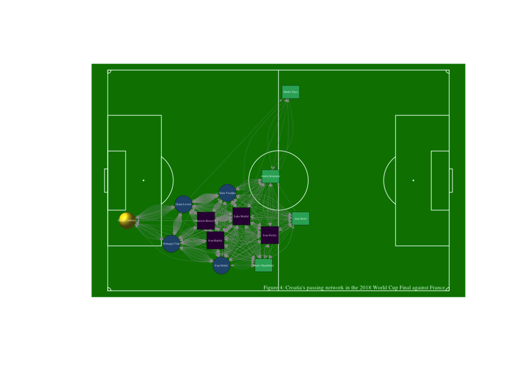

```r
# plot the croatia passing network from the World Cup final on soccer field
plot(final_croatia_image)
```

The directed passing network above represents Croatia’s passing from and to each player. Croatia had a significant amount of possession during the game and this can be seen in the network with he defenders and midfielders having significant connections with each other. However, when it came to moving the ball forward the number of connections drops. The lack of passes to the forward can be attributed to the French defensive style. They allow for the other team to have possession in their own half, but Croatia crossed to the French side they would press and prevent passes getting to their forwards. Modric seems to have the most diverse connections which makes sense since he usually controls the midfield for the Croatian team.

#### Betweenness Centrality and Closeness Centrality Statistics for Teams in the 2018 World Cup Semifinal and Final

The importance of a player to a team is hard to define. Every player plays a crucial role on the team; the success of the team depends on the individual contributions of each player. Although the performance of the team depends on every player, some players are more influential and contribute more than other players. The influence of players on the teams’ accomplishments depends on different factors. For instance, the position they play will have an impact on how much they interact with other players and the ball, thus, determining their influence during the game.

From [UNGAR Chapter 7: Actor Prominence](https://link.springer.com/book/10.1007/978-3-319-23883-8), we will use measures of centrality to determine the prominence of players on the teams in the 2018 World Cup semifinal and final. We will use closeness centrality which measures how close a given node is to other nodes in the network as well as betweenness centrality which measures to what extent a given node is positioned “between” pairs of other nodes in the network.

To determine which players were central to the directed networks of the France-Croatia final and France-Belgium semifinal, we referred to the [2012 article “A network theory analysis of football strategies” by Javier López Peña and Hugo Touchette](https://arxiv.org/pdf/1206.6904.pdf). In their article, they use closeness centrality and betweenness centrality to measure a player’s contribution to the team. Guided by their insights, we will use betweenness centrality to inform the extent to which ball-flow between the rest of the team depends on each player and closeness centrality to inform how well-connected each player.

##### Betweenness Centrality and Closeness Centrality for French Players in the Semifinal

```r
# betweenness for france semifinal
btwn.france_semi <- betweenness(france_semi.g) # calculating betweenness for france semifinal graph object
names(btwn.france_semi) <- V(france_semi.g)$name # grabbing player names from france semifinal graph object
ind <- order(-btwn.france_semi) # reordering in descending order
btwn.france_semi[ind][1:13] # displaying table of france semifinal betweenness centrality scores
```

```
##        N''Golo Kanté           Paul Pogba       Raphaël Varane
##          12.02674171           7.54403035           5.64971317
##    Antoine Griezmann      Benjamin Pavard   Samuel Yves Umtiti
##           5.25096901           4.53488637           4.05779881
##       Olivier Giroud Kylian Mbappé Lottin   Lucas Hernández Pi
##           2.95381498           1.64981376           0.96802648
##       Blaise Matuidi     Corentin Tolisso          Hugo Lloris
##           0.72530460           0.45943992           0.10833839
##       Djibril Sidibé
##           0.07112245
```

We observe here that Kanté, Pogba, and Varane have the largest betweenness centrality scores among French players in the semifinal with scores of 12.027, 7.544, and 5.650 respectively. This means that the impact of removing these three players from the 2018 World Cup semifinal would have a far greater effect than removing players like Sidibé with a betweenness centrality score of less than 0.1. These top three players are two midfielders and a defender for France. Further, from the large variation in betweenness scores, we see that there is a high dependence on a few important players in the French passing network for the France-Belgium semifinal.

```r
# closeness for france semifinal
closeness.france_semi <- closeness(france_semi.g) # calculating closeness for france semifinal graph object
names(closeness.france_semi) <- V(france_semi.g)$name # grabbing player names from france semifinal graph object
ind <- order(-closeness.france_semi) # reordering in descending order
closeness.france_semi[ind][1:13] # displaying table of france semifinal closeness centrality scores
```

```
##        N''Golo Kanté    Antoine Griezmann       Raphaël Varane
##           0.08333333           0.07692308           0.07142857
##           Paul Pogba      Benjamin Pavard   Samuel Yves Umtiti
##           0.07142857           0.06666667           0.06666667
##   Lucas Hernández Pi Kylian Mbappé Lottin       Olivier Giroud
##           0.06250000           0.06250000           0.06250000
##     Corentin Tolisso          Hugo Lloris       Blaise Matuidi
##           0.05882353           0.05882353           0.05555556
##       Djibril Sidibé
##           0.05263158
```

From our closeness centrality calculation, we see that Kanté, Griezmann, and Varane have the largest closeness centrality scores among French players in the semifinal with scores of 0.083, 0.077, and 0.071 respectively. Since closeness centrality is calculated out of 1, these are still very small scores that measure how well-connected a player is based on how easy it is for other players to reach them. These top three players are a midfielder, forward, and defender respectively.

From these two calculations of centrality, midfielder N’’Golo Kanté is clearly the most central to the passing network of the French team in the 2018 World Cup semifinal, followed closely by other key players including defender Varane, midfielder Pogba, and forward Griezemann.

##### Betweenness Centrality and Closeness Centrality for Belgian Players in the Semifinal

```r
# betweenness for belgium semifinal
btwn.belgium_semi <- betweenness(belgium_semi.g) # calculating betweenness for belgium semifinal graph object
names(btwn.belgium_semi) <- V(belgium_semi.g)$name # grabbing player names from belgium semifinal graph object
ind <- order(-btwn.belgium_semi) # reordering in descending order
btwn.belgium_semi[ind][1:14] # displaying table of france semifinal betweenness centrality scores
```

```
##                Eden Hazard             Thomas Meunier
##                 9.51997155                 8.98266060
##                Axel Witsel          Toby Alderweireld
##                 8.77884559                 6.95491862
##            Kevin De Bruyne             Jan Vertonghen
##                 6.86715261                 6.31003253
##               Nacer Chadli Marouane Fellaini-Bakkioui
##                 5.71862325                 2.97251161
##           Thibaut Courtois            Vincent Kompany
##                 1.54811668                 1.43259411
##  Yannick Ferreira Carrasco       Romelu Lukaku Menama
##                 1.23149395                 0.40691321
##    Mousa Sidi Yaya Dembélé      Michy Batshuayi Tunga
##                 0.24898918                 0.02717653
```

We observe here that Hazard, Meunier, and Witsel have the largest betweenness centrality scores among Belgian players in the semifinal with scores of 9.520, 8.983, and 8.779 respectively. This means that the impact of removing these three players from the 2018 World Cup semifinal would have a far greater effect than removing players like Tunga with a betweenness centrality score of less than 0.3. These top three players are a forward, a defender, and a midfielder respectfully. Further, from the large variation in betweenness scores, we see that there is a high dependence on a few important players in the Belgian passing network for the France-Belgium semifinal.

```r
# closeness for belgium semifinal
closeness.belgium_semi <- closeness(belgium_semi.g) # calculating closeness for belgium semifinal graph object
names(closeness.belgium_semi) <- V(belgium_semi.g)$name # grabbing player names from belgium semifinal graph object
ind <- order(-closeness.belgium_semi) # reordering in descending order
closeness.belgium_semi[ind][1:14] # displaying table of belgium semifinal closeness centrality scores
```

```
##                Axel Witsel            Kevin De Bruyne
##                 0.07142857                 0.06666667
##                Eden Hazard Marouane Fellaini-Bakkioui
##                 0.06666667                 0.06666667
##            Vincent Kompany           Thibaut Courtois
##                 0.06666667                 0.06250000
##             Jan Vertonghen          Toby Alderweireld
##                 0.06250000                 0.06250000
##    Mousa Sidi Yaya Dembélé             Thomas Meunier
##                 0.05882353                 0.05555556
##  Yannick Ferreira Carrasco               Nacer Chadli
##                 0.05263158                 0.05263158
##       Romelu Lukaku Menama      Michy Batshuayi Tunga
##                 0.04761905                 0.03703704
```

From our closeness centrality calculation, we see that Witsel, De Bruyne, and Hazard have the largest closeness centrality scores among Belgian players in the semifinal with scores of 0.071, 0.067, and 0.067 respectively. Since closeness centrality is calculated out of 1, these are still very small scores that measure how well-connected a player is based on how easy it is for other players to reach them. These top three players are two midfielders and a forward respectively.

From these two calculations of centrality, forward Eden Hazard and midfielder Axel Witsel are the most central to the passing network of the Belgian team in the 2018 World Cup semifinal, followed closely by other key players including midfielder De Bruyne.

##### Betweenness Centrality and Closeness Centrality for French Players in the Final

```r
# betweenness for france final
btwn.france_final <- betweenness(france_final.g) # calculating betweenness for france final graph object
names(btwn.france_final) <- V(france_final.g)$name # grabbing player names from france final graph object
ind <- order(-btwn.france_final) # reordering in descending order
btwn.france_final[ind][1:14] # displaying table of france final betweenness centrality scores
```

```
##                             Benjamin Pavard
##                                 16.59862245
##                               N''Golo Kanté
##                                  9.31564128
##                                  Paul Pogba
##                                  5.04142547
##                          Lucas Hernández Pi
##                                  4.59378058
##                           Antoine Griezmann
##                                  4.08051617
##                          Samuel Yves Umtiti
##                                  3.35455560
##                              Raphaël Varane
##                                  2.95348850
## Steven N''Kemboanza Mike Christopher Nzonzi
##                                  2.77595306
##                        Kylian Mbappé Lottin
##                                  1.66972167
##                              Olivier Giroud
##                                  1.41178683
##                            Corentin Tolisso
##                                  0.69743327
##                              Blaise Matuidi
##                                  0.32552612
##                                 Hugo Lloris
##                                  0.14723320
##                                 Nabil Fekir
##                                  0.03431579
```

We observe here that Pavard, Kanté, and Pogba have the largest betweenness centrality scores among French players in the final with scores of 16.599, 9.316, and 5.041 respectively. This means that the impact of removing these three players from the 2018 World Cup final would have a far greater effect than removing players like Fekir with a betweenness centrality score of less than 0.4. These top three players are a defender and two midfielders respectfully. Further, from the large variation in betweenness scores, we see that there is a high dependence on a few important players in the French passing network for the France-Croatia final.

```r
# closeness for france final
closeness.france_final <- closeness(france_final.g) # calculating closeness for france final graph object
names(closeness.france_final) <- V(france_final.g)$name # grabbing player names from france final graph object
ind <- order(-closeness.france_final) # reordering in descending order
closeness.france_final[ind][1:14] # displaying table of france final closeness centrality scores
```

```
##                               N''Golo Kanté
##                                  0.07692308
##                                  Paul Pogba
##                                  0.07142857
##                             Benjamin Pavard
##                                  0.06666667
##                          Samuel Yves Umtiti
##                                  0.06666667
##                              Raphaël Varane
##                                  0.06666667
##                           Antoine Griezmann
##                                  0.06666667
##                          Lucas Hernández Pi
##                                  0.06666667
##                                 Hugo Lloris
##                                  0.05882353
##                        Kylian Mbappé Lottin
##                                  0.05882353
##                              Olivier Giroud
##                                  0.05882353
## Steven N''Kemboanza Mike Christopher Nzonzi
##                                  0.05555556
##                              Blaise Matuidi
##                                  0.05263158
##                            Corentin Tolisso
##                                  0.05000000
##                                 Nabil Fekir
##                                  0.04000000
```

From our closeness centrality calculation, we see that Kanté, Pogba, and Pavard have the largest closeness centrality scores among French players in the final with scores of 0.077, 0.071, and 0.067 respectively. Since closeness centrality is calculated out of 1, these are still very small scores that measure how well-connected a player is based on how easy it is for other players to reach them. These top three players are two midfielders and a defender respectively.

From these two calculations of centrality, midfielders N’’Golo Kanté and Paul Pogba as well as defender Benjamin Pavard are the most central to the passing network of the French team in the 2018 World Cup final, followed closely by other key players including defenders Umtiti, Varane, and Pi as well as forward Griezmann.

##### Betweenness Centrality and Closeness Centrality for Croatian Players in the Final

```r
# betweenness for croatia final
btwn.croatia_final <- betweenness(croatia_final.g) # calculating betweenness for croatia final graph object
names(btwn.croatia_final) <- V(croatia_final.g)$name # grabbing player names from croatia final graph object
ind <- order(-btwn.croatia_final) # reordering in descending order
btwn.croatia_final[ind][1:13] # displaying table of croatia final betweenness centrality scores
```

```
##  Andrej Kramarić      Luka Modrić     Dejan Lovren     Ivan Rakitić
##     11.734465199     10.598220764      6.623765270      5.884060656
##    Šime Vrsaljko Marcelo Brozović     Domagoj Vida     Ivan Strinić
##      3.587870999      2.474019205      2.033953602      1.637292446
##     Ivan Perišić  Mario Mandžukić       Ante Rebić  Danijel Subašić
##      1.297302349      0.747418453      0.196715547      0.177823311
##      Marko Pjaca
##      0.007092199
```

We observe here that Kramarić, Modrić, and Lovren have the largest betweenness centrality scores among Croatian players in the final with scores of 11.734, 10.598, and 6.624 respectively. This means that the impact of removing these three players from the 2018 World Cup final would have a far greater effect than removing players like Pjaca with a betweenness centrality score of less than 0.01. These top three players are a forward, a midfielder, and a defender respectfully. Further, from the large variation in betweenness scores, we see that there is a high dependence on a few important players in the Croatian passing network for the France-Croatia final.

```r
# closeness for croatia final
closeness.croatia_final <- closeness(croatia_final.g) # calculating closeness for croatia final graph object
names(closeness.croatia_final) <- V(croatia_final.g)$name # grabbing player names from croatia final graph object
ind <- order(-closeness.croatia_final) # reordering in descending order
closeness.croatia_final[ind][1:13] # displaying table of croatia final closeness centrality scores
```

```
##      Luka Modrić Marcelo Brozović     Ivan Rakitić     Domagoj Vida
##       0.07692308       0.07692308       0.07142857       0.07142857
##     Dejan Lovren    Šime Vrsaljko     Ivan Perišić  Mario Mandžukić
##       0.07142857       0.07142857       0.07142857       0.06666667
##  Andrej Kramarić       Ante Rebić  Danijel Subašić     Ivan Strinić
##       0.06250000       0.06250000       0.06250000       0.05882353
##      Marko Pjaca
##       0.03703704
```

From our closeness centrality calculation, we see that Modrić, Brozović, and Rakitić have the largest closeness centrality scores among Croatian players in the final with scores of 0.077, 0.077, and 0.071 respectively. Since closeness centrality is calculated out of 1, these are still very small scores that measure how well-connected a player is based on how easy it is for other players to reach them. These top three players are midfielders for Croatia.

From these two calculations of centrality, midfielder Luka Modrić is the most central to the passing network of the Croatian team in the 2018 World Cup final, followed closely by other key players including midfielder Rakitić and defender Lovren.

Midfielders are constantly interacting with the ball; they are the connections between the defenders and the forward players. They dictate how much the team is moving back and forth on the field. Although defenders don’t interact with the ball as much as the midfielders do, they have sufficient interactions with the ball that it would show. Their job is to stop attacks from the opposing team and prevent the opposing team from scoring a goal. Ultimately, it suffices to conclude that some of the most valuable players to a team will be players who interact the most with the ball and well as other players. In this case, the midfielders and defenders are invaluable to the three teams that played in the 2018 Word Cup semifinal and final.

#### Modeling Sent and Received Passing Distributions for Teams in the 2018 World Cup Final and Semifinal

To explore the distribution of sent and received passes on each team in both games, we first constructed frequency tables of the number of passes sent and received per player. The below code is for the French and Croatian team in the France-Croatia final:

```r
france_final_passes_from <- table(france_final[, 1]) # creating frequency table from players in passes from column in france_final dataset
france_final_passes_to <- table(france_final[, 2]) # creating frequency table from players in passes to column in france_final dataset

croatia_final_passes_from <- table(croatia_final[, 1]) # creating frequency table from players in passes from column in croatia_final dataset
croatia_final_passes_to <- table(croatia_final[, 2]) # creating frequency table from players in passes to column in croatia_final dataset
```

Then, we constructed bar plots, where the color of each bar corresponds to the player’s position:

##### France in the 2018 World Cup Semifinal

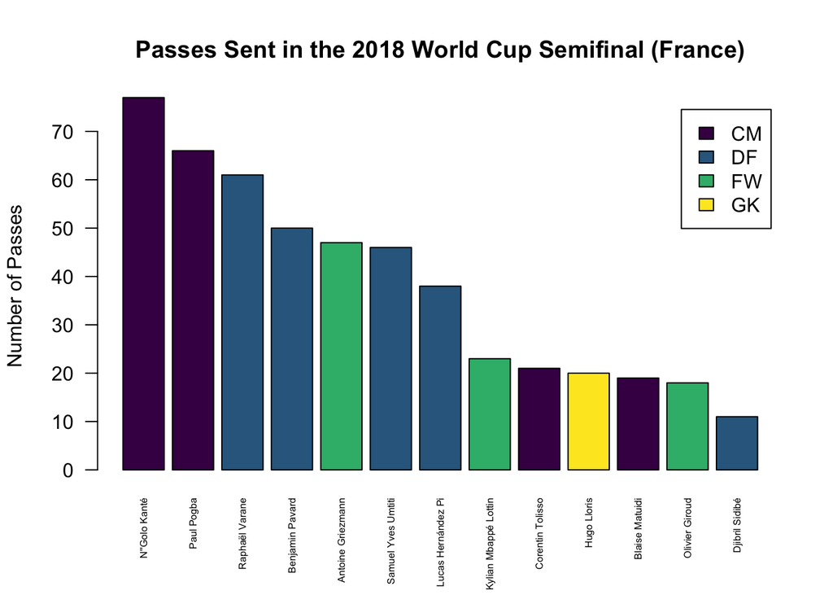

Figure 5: Barplot of passes sent on the French team in the 2018 World Cup semifinal where most midfielders and defenders send more passes than forwards and the goalkeeper.

```r
# plotting barplot of number of passes sent by french players in semifinal, colored based on the position of the player
barplot(df_from_semi_france_sent_ordered$Freq,decreasing = TRUE, names.arg = df_from_semi_france_sent_ordered$Var1, decreasing = TRUE, ylab = "Number of Passes" ,col = mycolors[df_from_semi_france_sent_ordered$Position],las=2,cex.names = 0.5, legend.text= levels(df_from_semi_france_sent_ordered$Position), args.legend = list("topright", fill =mycolors ),  main = "Passes Sent in the 2018 World Cup Semifinal (France)")
```

From the barplot of sent passes by players on the French team, we observe that midfielders Kanté and Pogba as well as defenders Varane and Pavard make up 254 of the 497 sent passes. This means that 4 of the 13 players make up over 50% of the sent passes by players on the French team in the France-Belgium semifinal.

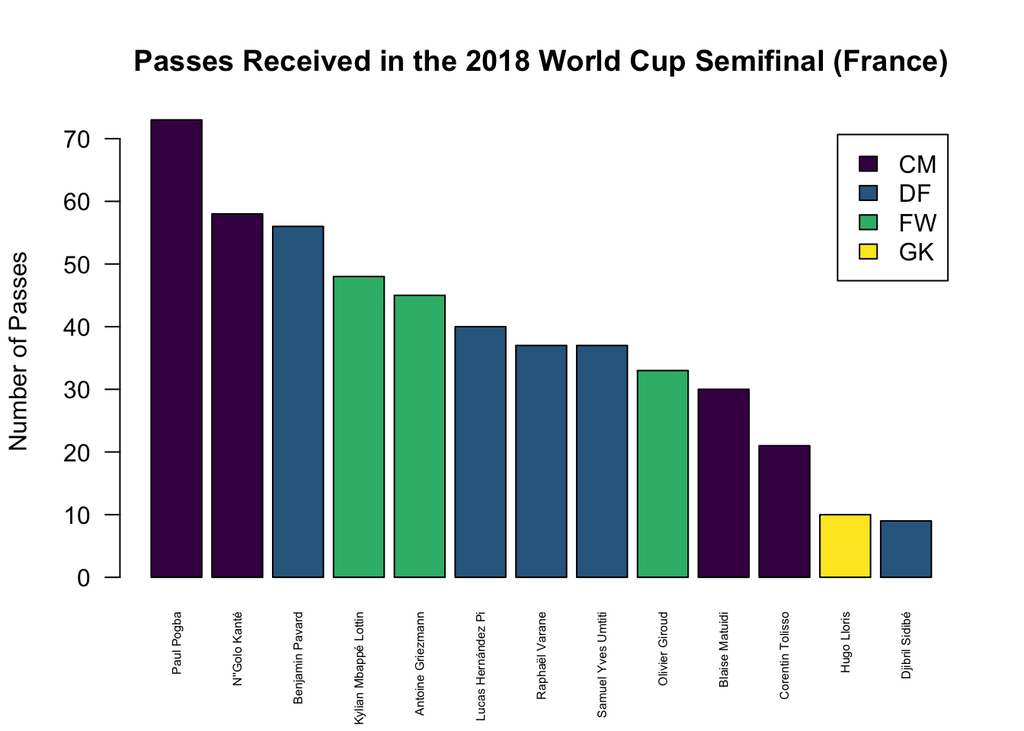

Figure 6: Barplot of passes receieved on the French team in the 2018 World Cup semifinal where no one or two positions receive the majority of the passes.

```r
# plotting barplot of number of passes received by french players in semifinal, colored based on the position of the player
barplot(df_to_semi_france_received_ordered$Freq,decreasing = TRUE, names.arg = df_to_semi_france_received_ordered$Var1, decreasing = TRUE, ylab = "Number of Passes" ,col = mycolors[df_to_semi_france_received_ordered$Position],las=2,cex.names = 0.5, legend.text= levels(df_to_semi_france_received_ordered$Position), args.legend = list("topright", fill = mycolors ),  main = "Passes Received in the 2018 World Cup Semifinal (France)")
```

From the barplot of received passes by players on the French team, we observe that midfielders Pogba and Kanté as well as defender Pavard and forward Mbappé Lottin make up 235 of the 497 received passes. This means that 4 of the 13 players make up 47% of the received passes by players on the French team in the France-Belgium semifinal.

We ran a power law fit test to determine if the distribution of sent and received passes on the French team in the French-Belgium semifinal was that of a power law distribution. We calculated an alpha value and p-value using the code below:

```r
# Creates Frequency Tables by Player for the French Team in the Semifinal
player_pass_france_s <- as.data.frame(table(connected_pass_france_semi$player.name))
player_recieve_france_s <- as.data.frame(table(connected_pass_france_semi$pass.recipient.name))
# Power Law Fit for the Passes by the French Team in the Semi
fit_power_law(player_pass_france_s$Freq)
```

```
## $continuous
## [1] FALSE
##
## $alpha
## [1] 4.765989
##
## $xmin
## [1] 46
##
## $logLik
## [1] -21.28143
##
## $KS.stat
## [1] 0.2240233
##
## $KS.p
## [1] 0.9240739
```

```r
# Power Law Fit for the Receptions by the French Team in the Semi
fit_power_law(player_recieve_france_s$Freq)
```

```
## $continuous
## [1] FALSE
##
## $alpha
## [1] 4.204698
##
## $xmin
## [1] 37
##
## $logLik
## [1] -28.65106
##
## $KS.stat
## [1] 0.1594471
##
## $KS.p
## [1] 0.9870999
```

**Power Law Fit for the Passes and Receptions by the French Team in the Semifinal:**

Using a frequency table for the number of passes and receptions made by the French team in the 2018 World Cup semifinal against Belgium, we were able to run a power law fit test to see if this data does in fact match a power law distribution. This analysis of the passes and receptions could be made separately, and each does tell its own story, but together the analyses make a better story. If we look at the alpha value for each, we see that alpha is 4.766 and 4.205 for the passes and receptions, respectively. A larger alpha implies that the data is heavily skewed, and a smaller alpha implies that the data is less skewed. So, we see that the passes and receptions made by each of the players on the French team are skewed at almost the same amount. If we look at the p-values, we see that the passes have a p-value of 0.924, which implies that it has a relatively high fit for the power law; the p-value for the receptions is 0.987, which also implies that the receptions by players have a higher fit for the power law. We can suggest that, in the semifinal, the French team was attempting to give the ball to their star players, which leads to a higher fit for the receptions. Anyone can steal and pass the ball, but which player you pass the ball to so that they can make an offensive play matters. If you give the ball to the star attackmen, then they have a good chance of scoring. This was a hard game for France, and they needed their star players to have the ball so they could score and thus win the game, which they did.

##### Belgium in the 2018 World Cup Semifinal

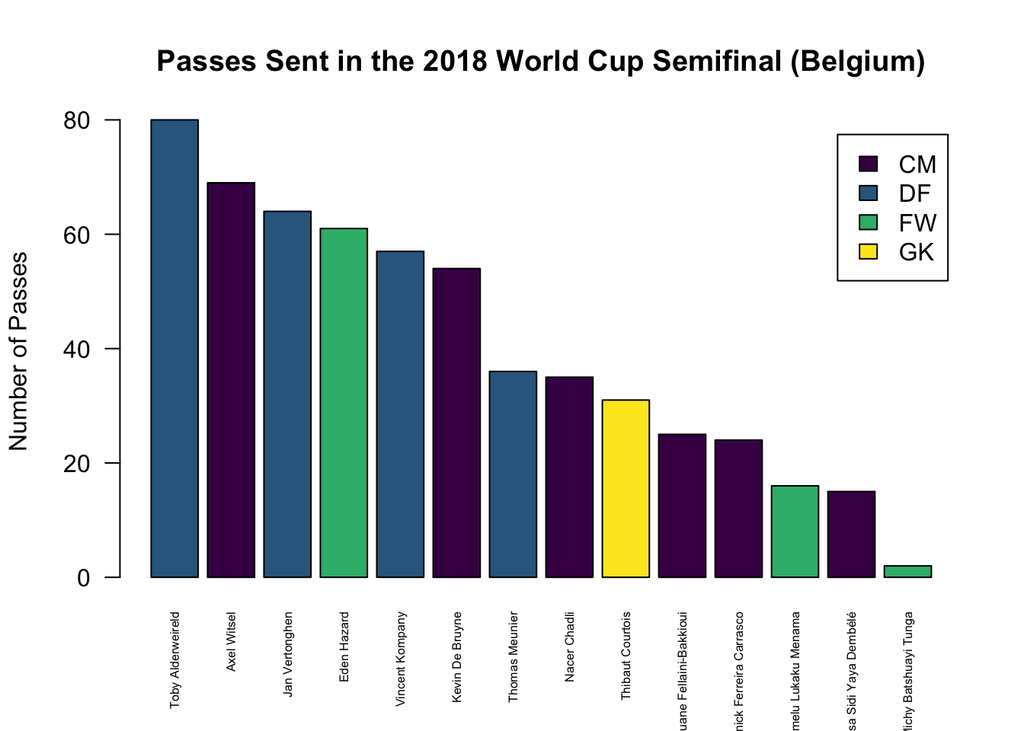

Figure 7: Barplot of passes sent on the Belgian team in the 2018 World Cup semifinal where most midfielders and defenders send more passes than forwards and the goalkeeper.

```r
# plotting barplot of number of passes sent by belgium players in semifinal, colored based on the position of the player
barplot(df_from_semi_bel_ordered$Freq,decreasing = TRUE, names.arg = df_from_semi_bel_ordered$Var1, decreasing = TRUE, ylab = "Number of Passes" ,col = mycolors[df_from_semi_bel_ordered$Position],las=2,cex.names = 0.5, legend.text= levels(df_from_semi_bel_ordered$Position), args.legend = list("topright", fill =mycolors ),  main = "Passes Sent in the 2018 World Cup Semifinal (Belgium)")
```

From the barplot of sent passes by players on the Belgian team, we observe that defenders Alderweireld and Vertonghen as well as midfielder Witsel and forward Hazard make up 274 of the 569 sent passes. This means that 4 of the 14 players make up 48% of the sent passes by players on the Belgian team in the France-Belgium semifinal.

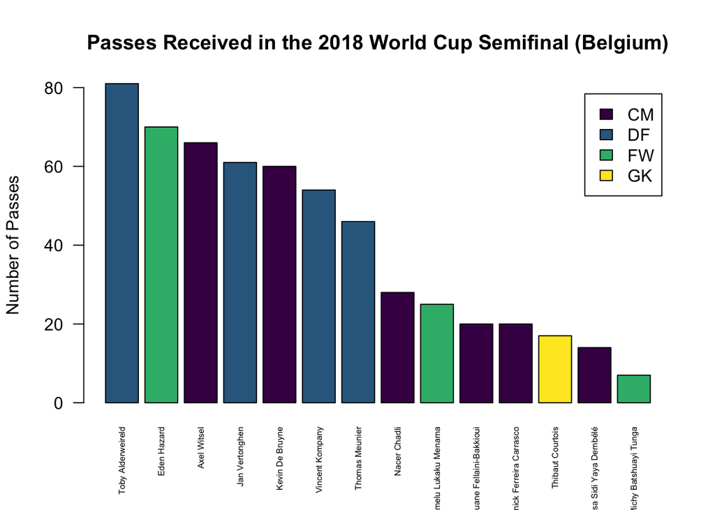

```r
# plotting barplot of number of passes received by belgium players in semifinal, colored based on the position of the player
barplot(df_to_semi_bel_ordered$Freq,decreasing = TRUE, names.arg = df_to_semi_bel_ordered$Var1, decreasing = TRUE, ylab = "Number of Passes" ,col = mycolors[df_to_semi_bel_ordered$Position],las=2,cex.names = 0.5, legend.text= levels(df_to_semi_bel_ordered$Position), args.legend = list("topright", fill =mycolors ),  main = "Passes Received in the 2018 World Cup Semifinal (Belgium)")
```

From the barplot of received passes by players on the Belgian team, we observe that defenders Alderweireld and Vertonghen as well as forward Hazard and midfielder Witsel make up 278 of the 569 sent passes. This means that 4 of the 14 players make up 49% of the sent passes by players on the Belgian team in the France-Belgium semifinal.

Then, we ran a power law fit test to determine if the distribution of sent and received passes on the Belgian team in the French-Belgium semifinal was that of a power law distribution. We calculated an alpha value and p-value using the code below:

```r
# Creates Frequency Tables by Player for the Belgian Team in the Semi
player_pass_belgium_s <- as.data.frame(table(connected_pass_belgium_semi$player.name))
player_recieve_belgium_s <- as.data.frame(table(connected_pass_belgium_semi$pass.recipient.name))
# Power Law Fit for the Passes by the Belgian Team in the Final
fit_power_law(player_pass_belgium_s$Freq)
```

```
## $continuous
## [1] FALSE
##
## $alpha
## [1] 7.322372
##
## $xmin
## [1] 61
##
## $logLik
## [1] -12.51253
##
## $KS.stat
## [1] 0.1499336
##
## $KS.p
## [1] 0.9999908
```

```r
# Power Law Fit for the Receptions by the Belgian Team in the Final
fit_power_law(player_recieve_belgium_s$Freq)
```

```
## $continuous
## [1] FALSE
##
## $alpha
## [1] 7.590767
##
## $xmin
## [1] 60
##
## $logLik
## [1] -15.61329
##
## $KS.stat
## [1] 0.1467647
##
## $KS.p
## [1] 0.9999191
```

**Power Law Fit for the Passes and Receptions by the Belgian Team in the Semifinal:**

Using a frequency table for the number of passes and receptions made by the Belgian team in the 2018 World Cup semifinal against France, we were able to run a power law fit test to see if this data does in fact match a power law distribution. This analysis of the passes and receptions could be made separately, and each does tell its own story, but together the analyses make a better story. If we look at the alpha value for each, we see that alpha is 7.322 and 7.591 for the passes and receptions, respectively. A larger alpha implies that the data is heavily skewed, and a smaller alpha implies that the data is less skewed. So, we see that the passes and receptions made by each of the players on the Belgian team are skewed at almost the same amount, but this alpha is very high, so the data we collected is very skewed. If we look at the p-values, we see that the passes have a p-value of 0.999, which implies that it has a very high fit for the power law; the p-value for the receptions is also 0.999, which again implies that the receptions by players have a very high fit for the power law. We can suggest that, in the semifinal, the star players on the Belgian team had the vast majority of control of the ball. This would lead us to believe that the Belgian team is not as deep in terms of talent, and that they were giving it to their star players because this was a very tough game for them. The star players on the Belgian team needed to have the ball because they possessed the highest ability to score a goal against the veteran French team. Belgium did lose this game, but the score was 1-0, which suggests that both teams were playing very hard and had similar strategies.

##### France in the 2018 World Cup Final

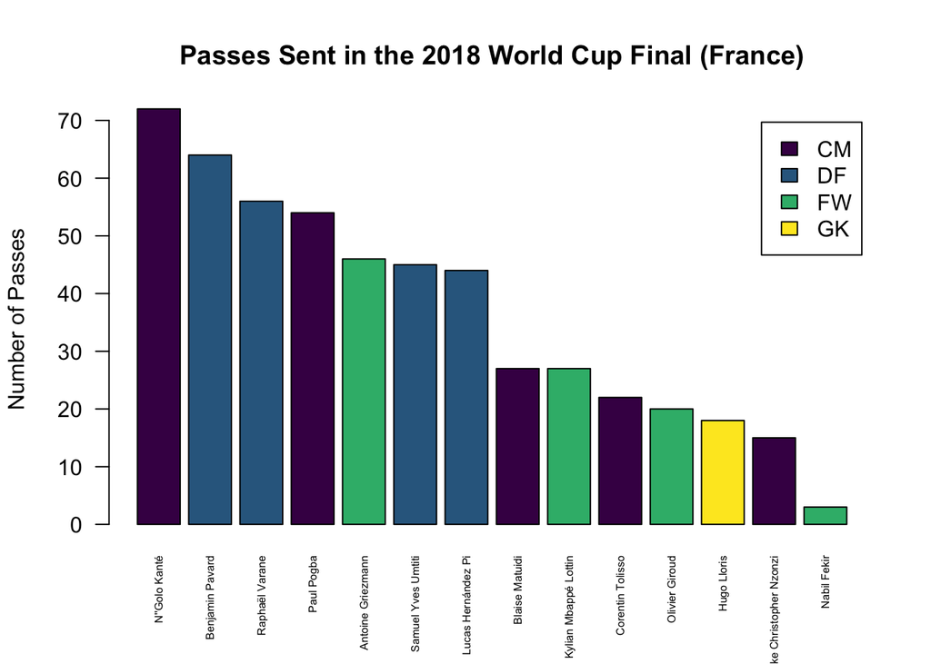

Figure 9: Barplot of passes sent on the French team in the 2018 World Cup final where most midfielders and defenders send more passes than forwards and the goalkeeper.

```r
# plotting barplot of number of passes sent by french players in final, colored based on the position of the player
barplot(df_from_final_france_sent_ordered$Freq,decreasing = TRUE, names.arg = df_from_final_france_sent_ordered$Var1, decreasing = TRUE, ylab = "Number of Passes" ,col = mycolors[df_from_final_france_sent_ordered$Position],las=2,cex.names = 0.5, legend.text= levels(df_from_final_france_sent_ordered$Position), args.legend = list("topright", fill =mycolors ),  main = "Passes Sent in the 2018 World Cup Final (France)")
```

From the barplot of sent passes by players on the French team, we observe that midfielders Kanté and Pogba as well as defenders Pavard and Varane make up 246 of the 513 sent passes. This means that 4 of the 14 players make up 48% of the sent passes by players on the French team in the France-Croatia final.

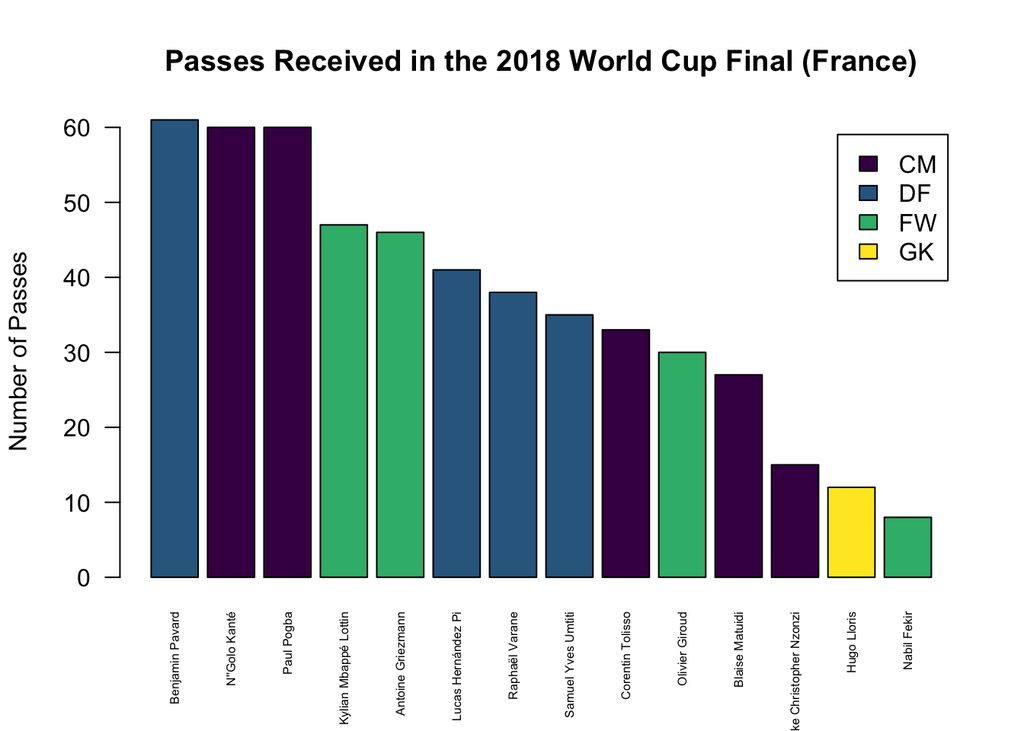

Figure 10: Barplot of passes received on the French team in the 2018 World Cup final where no one or two positions receive the majority of the passes.

```r
# plotting barplot of number of passes received by french players in final, colored based on the position of the player
barplot(df_to_final_france_received_ordered$Freq,decreasing = TRUE, names.arg = df_to_final_france_received_ordered$Var1, decreasing = TRUE, ylab = "Number of Passes" ,col = mycolors[df_to_final_france_received_ordered$Position],las=2,cex.names = 0.5, legend.text= levels(df_to_final_france_received_ordered$Position), args.legend = list("topright", fill = mycolors ),  main = "Passes Received in the 2018 World Cup Final (France)")
```

From the barplot of received passes by players on the French team, we observe that midfielders Kanté and Pogba as well as defender Pavard and forward Mbappé Lottin make up 228 of the 513 sent passes. This means that 4 of the 14 players make up 44% of the received passes by players on the French team in the France-Croatia final.

Again, we ran a power law fit test to determine if the distribution of sent and received passes on the French team in the Croatia-French final was that of a power law distribution. We calculated an alpha value and p-value using the code below:

```r
# Creates Frequency Tables by Player for the French Team in the Final
player_pass_france_f <- as.data.frame(table(connected_pass_france_final$player.name))
player_recieve_france_f <- as.data.frame(table(connected_pass_france_final$pass.recipient.name))
# Power Law Fit for the Passes by the French Team in the Final
fit_power_law(player_pass_france_f$Freq)
```

```
## $continuous
## [1] FALSE
##
## $alpha
## [1] 5.113934
##
## $xmin
## [1] 44
##
## $logLik
## [1] -23.97204
##
## $KS.stat
## [1] 0.2009379
##
## $KS.p
## [1] 0.9400531
```

```r
# Power Law Fit for the Receptions by the French Team in the Final
fit_power_law(player_recieve_france_f$Freq)
```

```
## $continuous
## [1] FALSE
##
## $alpha
## [1] 3.286734
##
## $xmin
## [1] 30
##
## $logLik
## [1] -38.51439
##
## $KS.stat
## [1] 0.1673758
##
## $KS.p
## [1] 0.9420751
```

##### Croatia in the 2018 World Cup Final

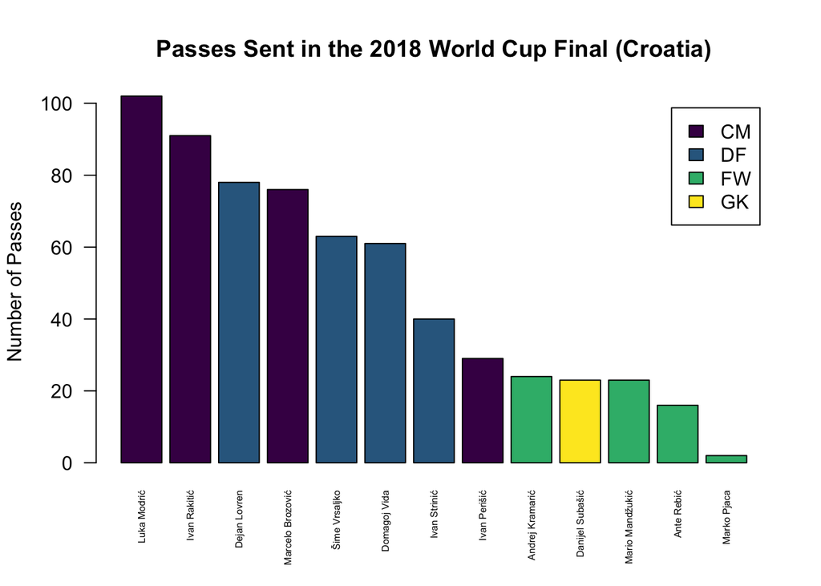

Figure 11: Barplot of passes sent on the Croatian team in the 2018 World Cup final where all midfielders and defenders send more passes than forwards and the goalkeeper.

```r
# plotting barplot of number of passes sent by croatian players in final, colored based on the position of the player
barplot(df_from_final_croatia_sent_ordered$Freq,decreasing = TRUE, names.arg = df_from_final_croatia_sent_ordered$Var1, decreasing = TRUE, ylab = "Number of Passes" ,col = mycolors[df_from_final_croatia_sent_ordered$Position],las=2,cex.names = 0.5, legend.text= levels(df_from_final_croatia_sent_ordered$Position), args.legend = list("topright", fill =mycolors ),  main = "Passes Sent in the 2018 World Cup Final (Croatia)")
```

From the barplot of sent passes by players on the Croatian team, we observe that midfielders Modrić, Rakitić, and Brozović as well as defender Lovren make up 347 of the 628 sent passes. This means that 4 of the 13 players make up 55% of the sent passes by players on the Croatian team in the France-Croatia final.

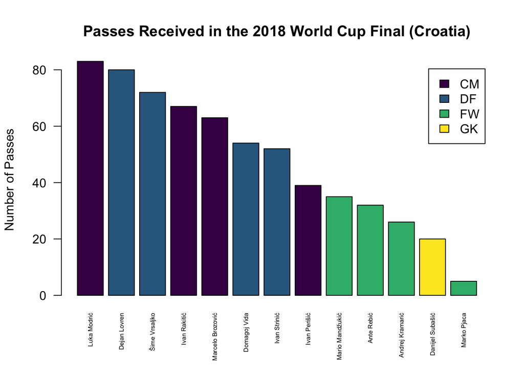

Figure 12: Barplot of passes received on the Croatian team in the 2018 World Cup final where all midfielders and defenders receive more passes than forwards and the goalkeeper.

```r
# plotting barplot of number of passes received by croatian players in final, colored based on the position of the player
barplot(df_to_final_croatia_receieved_ordered$Freq,decreasing = TRUE, names.arg = df_to_final_croatia_receieved_ordered$Var1, decreasing = TRUE, ylab = "Number of Passes" ,col = mycolors[df_to_final_croatia_receieved_ordered$Position],las=2,cex.names = 0.5, legend.text= levels(df_to_final_croatia_receieved_ordered$Position), args.legend = list("topright", fill =mycolors ),  main = "Passes Received in the 2018 World Cup Final (Croatia)")
```

From the barplot of received passes by players on the Croatian team, we observe that midfielders Modrić and Rakitić as well as defenders Lovren and Vrsaljko make up 302 of the 628 sent passes. This means that 4 of the 13 players make up 48% of the sent passes by players on the Croatian team in the France-Croatia final.

Lastly, we ran a power law fit test to determine if the distribution of sent and received passes on the Croatian team in the Croatia-French final was that of a power law distribution. We calculated an alpha value and p-value using the code below:

```r
# Creates Frequency Tables by Player for the Croatian Team in the Final
player_pass_croatia_f <- as.data.frame(table(connected_pass_croatia_final$player.name))
player_recieve_croatia_f <- as.data.frame(table(connected_pass_croatia_final$pass.recipient.name))
# Power Law Fit for the Passes by the Croatian Team in the Final
fit_power_law(player_pass_croatia_f$Freq)
```

```
## $continuous
## [1] FALSE
##
## $alpha
## [1] 1.882901
##
## $xmin
## [1] 16
##
## $logLik
## [1] -57.85151
##
## $KS.stat
## [1] 0.2305399
##
## $KS.p
## [1] 0.5463998
```

```r
# Power Law Fit for the Receptions by the Croatian Team in the Final
fit_power_law(player_recieve_croatia_f$Freq)
```

```
## $continuous
## [1] FALSE
##
## $alpha
## [1] 6.342012
##
## $xmin
## [1] 63
##
## $logLik
## [1] -17.04953
##
## $KS.stat
## [1] 0.199379
##
## $KS.p
## [1] 0.9886691
```

**Power Law Fit for the Passes and Receptions by the Croatian Team in the Final:**

Using a similar frequency table, like the one used above, for the number of passes and receptions made by the Croatian team in the 2018 World Cup final, we were able to run a power-law fit test to see if this data does in fact match a power law distribution. This analysis of the passes and receptions could be made separately, and each does tell its own story, but together the analyses make a better story. If we look at the alpha value for each, we see that alpha is 1.883 and 6.342 for the passes and receptions, respectively. A larger alpha implies that the data is heavily skewed, and a smaller alpha implies that the data is less skewed. We see that the number of passes made by each of the Croatian players is less skewed, but the receptions are very skewed. If we look at the p-values, we see that the passes have a p-value of 0.546, which implies that it has a relatively low fit for the power law. The number of passes is more evenly distributed because anyone can steal the ball, and thus make a pass. Conversely, we see that the p-value for the receptions is 0.989, which says that all of the receptions made do fit the power law very well. This makes sense because when looking to advance up the field, you want to pass it to your best players so that they may score a goal, which makes sense because France was in control of this game from the start. So, a few players receive the majority of the passes, whereas the rest of the players only receive the ball a few times because you want your best players to have control of the ball so that you can score goals and win the game. In the context of the game, we believe that the reason we came to these conclusions is that the defenders are stealing the ball and making passes, but they are passing to the offensive players so that they can counterattack and score. One of the most effective ways to score a goal in soccer is to quickly get control of the ball while the other team is attacking and make a lightning-quick drive for the goal because the other team is focused on their own attack. Counterattacks are effective plays and lead to a good shot for a team to score a goal, which Croatia needed in this game because France was leading from the start.

The higher centrality scores as well as the high number of passes sent and received by midfielders and defenders on each team across both games verifies the findings from the 2017 article [Midfielder as the prominent participant in the building attack: A network analysis of national teams in FIFA World Cup 2014 by Clemente, Filipe Manuel et al.](https://www.tandfonline.com/doi/abs/10.1080/24748668.2015.11868825) on the 2014 World Cup that midfielders and defenders are prominent nodes in passing networks using degree prestige, prestige, and betweenness centrality. A 2020 article [Player position relationships with centrality in the passing network of world cup soccer teams: Win/loss match comparisons also by Clemente, Filipe Manuel et al.](https://www.sciencedirect.com/science/article/pii/S0960077920300242#bib0007) concludes that midfielders and defenders are critical links in the passing network.

#### Limitations and Future Work

While these passing network analyses offer insights into playing strategy and key players, there are multiple ways that these analyses may be refined or extended in the future. By standardizing by playing time, our analyses of pass distributions across teams in different 2018 World Cup games would more accurately reflect team dynamics and key player positions in sending and receiving passes on different teams. Further, by utilizing the starting and ending coordinates of passes from the [Dato-Futbol/passing-networks GitHub repository](https://github.com/Dato-Futbol/passing-networks), our passing network visualizations could be extended from what the article [Using Network Science to Analyse Football Passing Networks: Dynamics, Space, Time, and the Multilayer Nature of the Game by Buldú, Javier M. et al.](https://www.frontiersin.org/articles/10.3389/fpsyg.2018.01900/full) calls player passing networks where the network nodes are players on a team to pitch networks, where network nodes are regions on the field connected through passes made by players on the field positioned at these different regions. This type of network would lend itself to creating a network of player positions and accurate mappings of passes between them based on real-time coordinates data. It would even be possible to construct a heatmap of where passes occur across the field.

#### References

1. Nepusz, T., & Csardi, G. (n.d.). Fit_power_law: Fitting a power-law distribution function to discrete data. RDocumentation. Retrieved April 19, 2022, from (https://www.rdocumentation.org/packages/igraph/versions/1.3.0/topics/fit_power_law)
2. Luke, Douglas. 2015. A User’s Guide to Network Analysis in R. (https://link.springer.com/book/10.1007/978-3-319-23883-8)
3. Peña, Javier López and Hugo Touchette. 2012. A network theory analysis of football strategies. (https://arxiv.org/pdf/1206.6904.pdf)
4. Buldú, Javier M. et al. 2018. Using Network Science to Analyse Football Passing Networks: Dynamics, Space, Time, and the Multilayer Nature of the Game. (https://www.frontiersin.org/articles/10.3389/fpsyg.2018.01900/full)
5. Clemente, Filipe Manuel et al. 2017. Midfielder as the prominent participant in the building attack: A network analysis of national teams in FIFA World Cup 2014. (https://www.tandfonline.com/doi/abs/10.1080/24748668.2015.11868825)
6. Clemente, Filipe Manuel et al. 2020. Player position relationships with centrality in the passing network of world cup soccer teams: Win/loss match comparisons. (https://www.sciencedirect.com/science/article/pii/S0960077920300242#bib0007)